# Predictive Modeling

This notebook provides the code for classification.

Our proposed method first split the 20 samples into training (n=14) and testing (n=6) set. We first trained a preliminary classifier on the training set with scanner data that categorized the samples into three classes (good, bad and uncertain). We made predictions on the test data, then the test samples that were classified as “uncertain” were taken to a more refined classifier trained with high resolution VR measurements. The “uncertain” samples were then predicted again to either “good” or “bad”.

## Label the data with ground truth

We first give all the samples of a ground truth label of either good or bad using K-means clustering.

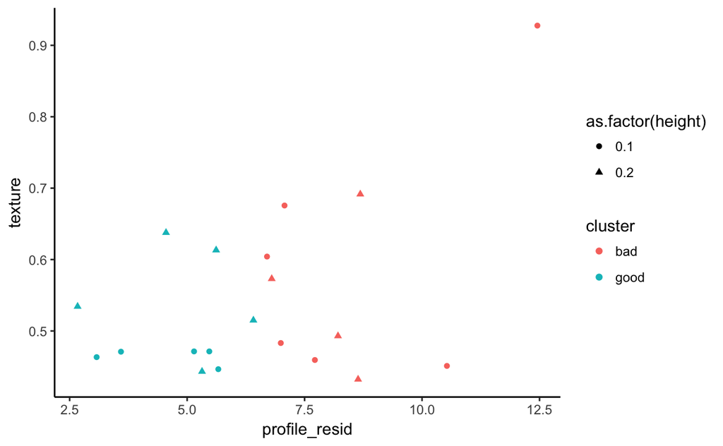

```r
# read the quality metrics
qualitydf<-read.csv("qualitydf.csv",header = T)
# clustering with profile resid and roughness to give the samples a ground "truth"
set.seed(4747)
library(ggplot2)
quality_cluster<-kmeans(qualitydf[,c(1,2)],2)
# label the cluster
cluster<-quality_cluster$cluster
for(i in 1:length(cluster)){
  cluster[i]<-ifelse(cluster[i]==2,"bad","good")
}
# factorize the cluster label and create a big data frame
ground_truth<-as.factor(cluster)
bigdf<-cbind(qualitydf,ground_truth)
# plot the clustering result
## ggplot
ggplot(bigdf,aes(x=texture,y=profile_resid,shape=as.factor(height),color=cluster))+geom_point()+coord_flip()+theme_classic()
```

```r
# normal plot
goodmeanX<-mean(bigdf[which(bigdf$ground_truth=="good"),]$profile_resid)
badmeanX<-mean(bigdf[which(bigdf$ground_truth=="bad"),]$profile_resid)
goodmeanY<-mean(bigdf[which(bigdf$ground_truth=="good"),]$texture)
badmeanY<-mean(bigdf[which(bigdf$ground_truth=="bad"),]$texture)
plot(
 bigdf$profile_resid,bigdf$texture,col=as.factor(bigdf$ground_truth),ylab="Roughness (%)",xlab="Profile Residual (um^2)",xlim=c(2,16),pch=20
)
points(goodmeanX,goodmeanY,cex=1.5,col="red",pch=18)
```

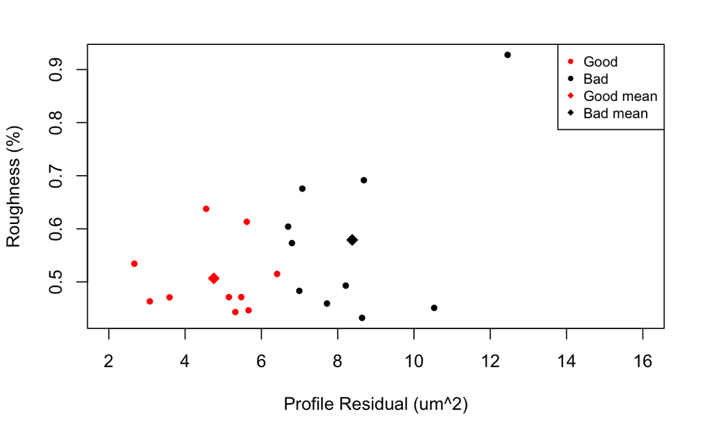

```r
points(badmeanX,badmeanY,cex=1.5,col="black",pch=18)
legend("topright", legend=c("Good", "Bad","Good mean","Bad mean"),pch=c(20,20,18,18),
       col=c("red", "black","red","black"),cex=0.8)
```

The clustering result shows that nGood = nBad = 10

## Scanner classifier only

We now train a classifier with only scanner data. We use this classifier as a comparison to our proposed method to evaluate their predictive strength.

```r
# read the scanner height data
library(readr)
folder <- "measurements/scanner/"
file_list <- list.files(path = folder, pattern = "*.obj")

scannerdf<-data.frame()
for (i in 1:length(file_list)){
  scanner<-read_delim(paste(folder, file_list[i],sep='')," ", escape_double = FALSE, col_names = FALSE,
    trim_ws = TRUE, skip = 3)[,-1]
  name<-paste("scanner-",substr(file_list[i],start=1,stop=nchar(file_list[i])-4),sep ='')
  assign(name, scanner)

  X<-scanner$X2
  Y<-scanner$X3
  Z<-scanner$X4

  # trim X, Y and Z that are out of range
  xTrim<-which(abs(X)<=32)
  Y<-Y[xTrim]
  Z<-Z[xTrim]
  X<-X[xTrim]

  yTrim<-which(abs(Y)<=32)
  Z<-Z[yTrim]
  X<-X[yTrim]
  Y<-Y[yTrim]

  # put Z of each sample into the rows of the df
  scannerdf<-rbind(scannerdf,Z)
}

# omit NAs with zero
scannerdf[is.na(scannerdf)]<-0
dim(scannerdf)
```

[output not shown]

```r
# split into train and test by 7:3
# sample 3 from good and 3 from bad
set.seed(4747)
goodind<-sample(which(bigdf$ground_truth=="good"),3,replace=FALSE)
badind<-sample(which(bigdf$ground_truth=="bad"),3,replace=FALSE)
testind<-c(goodind,badind)
bigdf[testind,]
```

```
     texture profile_resid height fill speed ground_truth
5  0.4465157      5.663563    0.1   20    60         good
8  0.4709890      3.592076    0.1   40    60         good
11 0.4713982      5.147370    0.1   60    60         good
9  0.4593629      7.719039    0.1   60    20          bad
3  0.9276159     12.454372    0.1  100    60          bad
17 0.5731126      6.800534    0.2   40    20          bad
```

```r
# extract pca from scanner train set
scanner_mat_train<-as.matrix(scannerdf)[-testind,]
pca<-prcomp(scanner_mat_train,center=TRUE)
summary(pca)
```

```
Importance of components:
                            PC1      PC2      PC3     PC4       PC5       PC6
Standard deviation     225.2793 181.8541 160.2968 133.847 125.31491 107.95208
Proportion of Variance   0.2493   0.1625   0.1262   0.088   0.07714   0.05725
Cumulative Proportion    0.2493   0.4118   0.5380   0.626   0.70313   0.76037
                            PC7     PC8      PC9    PC10     PC11     PC12     PC13
Standard deviation     99.09473 93.0166 84.72606 82.4575 78.17306 74.53725 68.29389
Proportion of Variance  0.04824  0.0425  0.03526  0.0334  0.03002  0.02729  0.02291
Cumulative Proportion   0.80861  0.8511  0.88638  0.9198  0.94980  0.97709  1.00000
                            PC14
Standard deviation     4.213e-13
Proportion of Variance 0.000e+00
Cumulative Proportion  1.000e+00
```

```r
scanner_pca_train<-pca$x[,1:4]
colnames(scanner_pca_train)<-c("scanner_PC1","scanner_PC2","scanner_PC3","scanner_PC4")
# extract pca from scanner test set
scanner_mat_test<-as.matrix(scannerdf)[testind,]
scanner_pca_test<-prcomp(scanner_mat_test,center=TRUE)$x[,1:4]
colnames(scanner_pca_test)<-c("scanner_PC1","scanner_PC2","scanner_PC3","scanner_PC4")
```

```r
# create the training data frame
train_df<-data.frame(cbind(scanner_pca_train,bigdf[-testind,][,-c(1,2)]))
test_df<-data.frame(cbind(scanner_pca_test,bigdf[testind,][,-c(1,2)]))
```

### Train a Random Forest

```r
# using only scanner pca
library(Metrics)
library(caret)
# 3-fold cv
control<-trainControl(method="cv",number=3,summaryFunction=twoClassSummary,classProbs = TRUE)
seed <- 47
metric <- "ROC"  # use ROC metric
set.seed(seed)
mtry <- 1:7
tunegrid <- expand.grid(.mtry=mtry)
rf_pca <- train(ground_truth~., data=train_df, method="rf", metric=metric, tuneGrid=tunegrid, trControl=control,preProcess = c("scale", "center"))
rf_pca
```

```
Random Forest

14 samples
 7 predictor
 2 classes: 'bad', 'good'

Pre-processing: scaled (7), centered (7)
Resampling: Cross-Validated (3 fold)
Summary of sample sizes: 8, 10, 10
Resampling results across tuning parameters:

  mtry  ROC        Sens       Spec
  1     0.5648148  0.3333333  0.5555556
  2     0.5555556  0.2777778  0.5555556
  3     0.5185185  0.1666667  0.5555556
  4     0.5000000  0.1666667  0.5555556
  5     0.4814815  0.2777778  0.5555556
  6     0.5185185  0.2777778  0.5555556
  7     0.5000000  0.2777778  0.5555556

ROC was used to select the optimal model using the largest value.
The final value used for the model was mtry = 1.
```

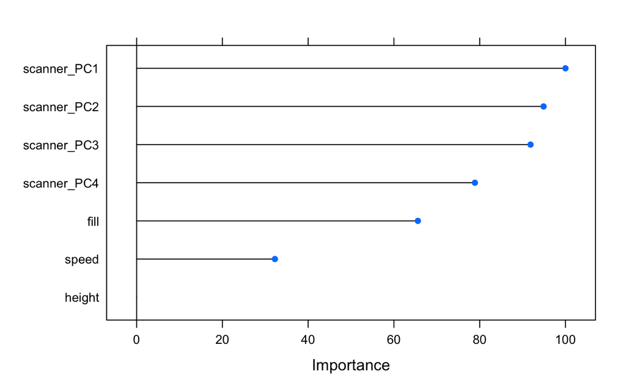

```r
plot(varImp(rf_pca))
```

```r
pred_scanner<-predict(rf_pca,test_df)
confusionMatrix(predict(rf_pca,test_df),test_df$ground_truth)
```

```
Confusion Matrix and Statistics

          Reference
Prediction bad good
      bad    2    1
      good   1    2

               Accuracy : 0.6667
                 95% CI : (0.2228, 0.9567)
    No Information Rate : 0.5
    P-Value [Acc > NIR] : 0.3437

                  Kappa : 0.3333
 Mcnemar's Test P-Value : 1.0000

            Sensitivity : 0.6667
            Specificity : 0.6667
         Pos Pred Value : 0.6667
         Neg Pred Value : 0.6667
             Prevalence : 0.5000
         Detection Rate : 0.3333
   Detection Prevalence : 0.5000
      Balanced Accuracy : 0.6667

       'Positive' Class : bad
```

The most optimal cv ROC score is 0.5648. The test accuracy is 0.6667.

```r
# plot variable importance
varImp(rf_pca)
```

```
rf variable importance

            Overall
scanner_PC1  100.00
scanner_PC2   94.90
scanner_PC3   91.86
scanner_PC4   78.88
fill          65.58
speed         32.24
height         0.00
```

## Proposed Method using both scanner and high resolution

### Training the first classifier

The first classifier is trained with only scanner data. We first label the training samples with good, bad or uncertain. Then we predict the test samples. This is a multiclass classification.

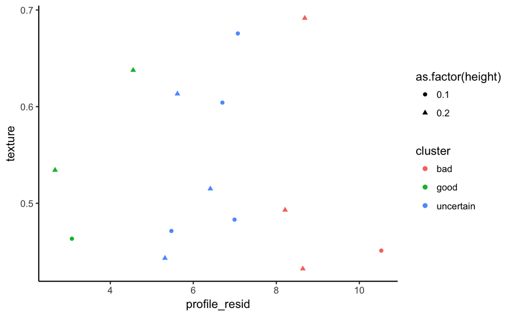

```r
# split into train and test
new_train<-qualitydf[-testind,]
new_test<-qualitydf[testind,]
# cluster the training samples into good or bad
set.seed(47)
clustering<-kmeans(new_train[,c(1,2)],3)
cluster<-clustering$cluster
for(i in 1:length(cluster)){
  cluster[i]<-ifelse(cluster[i]==3,"good",ifelse(cluster[i]==2,"uncertain","bad"))
}
cluster<-as.factor(cluster)
new_train<-cbind(new_train,cluster)
# plot the clustering result
ggplot(new_train,aes(x=texture,y=profile_resid,shape=as.factor(height),color=cluster))+geom_point()+coord_flip()+theme_classic()
```

nGood:nBad:nUncertain = 3:4:7

```r
# a multiclass summary function that will be used for multiclass classification
library(compiler)
multiClassSummary <- cmpfun(function (data, lev = NULL, model = NULL){
#Load Libraries
require(Metrics)
require(caret)
#Check data
if (!all(levels(data[, "pred"]) == levels(data[, "obs"])))
stop("levels of observed and predicted data do not match")
#Calculate custom one-vs-all stats for each class
prob_stats <- lapply(levels(data[, "pred"]), function(class){
#Grab one-vs-all data for the class
pred <- ifelse(data[, "pred"] == class, 1, 0)
obs <- ifelse(data[, "obs"] == class, 1, 0)
prob <- data[,class]
#Calculate one-vs-all AUC and logLoss and return
cap_prob <- pmin(pmax(prob, .000001), .999999)
prob_stats <- c(auc(obs, prob), logLoss(obs, cap_prob))
names(prob_stats) <- c('ROC', 'logLoss')
return(prob_stats)
})
prob_stats <- do.call(rbind, prob_stats)
rownames(prob_stats) <- paste('Class:', levels(data[, "pred"]))
#Calculate confusion matrix-based statistics
CM <- confusionMatrix(data[, "pred"], data[, "obs"])
#Aggregate and average class-wise stats
#Todo: add weights
class_stats <- cbind(CM$byClass, prob_stats)
class_stats <- colMeans(class_stats)
#Aggregate overall stats
overall_stats <- c(CM$overall)
#Combine overall with class-wise stats and remove some stats we don't want
stats <- c(overall_stats, class_stats)
stats <- stats[! names(stats) %in% c('AccuracyNull',
'Prevalence', 'Detection Prevalence')]
#Clean names and return
names(stats) <- gsub('[[:blank:]]+', '_', names(stats))
return(stats)
})
```

```r
predict(rf_scanner,scanner_test_df)
```

```
[1] uncertain uncertain uncertain uncertain uncertain uncertain
Levels: bad good uncertain
```

### Training the second classifier

```r
# read in the VR high resolution measurement matrices
folder <- "measurements/matrix/"
file_list <- list.files(path = folder, pattern = "*.csv")

mat_pca<-matrix(0,nrow=length(file_list),ncol=1520*1628)
namelst<-list()
for (i in 1:length(file_list)){
    df<- read.csv(paste(folder, file_list[i],sep=''),header=F,skip=23)
    df[is.na(df)]<-0
    #imputedf<-DMwR::knnImputation(df,k=5)
    name<-substr(file_list[i],start=11,stop=nchar(file_list[i])-17)
    namelst<-c(namelst,name)
    if (dim(df)[2]>1628){      # fix a minor issue where one matrix is reversed
      df<-df[1:1520,1:1628]
    }
    if (dim(df)[2]==1520){
      df<-t(df)
    }
    assign(name, df)
    mat_pca[i,]<-as.vector(as.matrix(df))
}
length(file_list)
dim(mat_pca)
```

```r
# export the high resolution matrices for matlab umpca code
trainind<-seq(1,20,by=1)[-testind]
# clear previous files before writing the new ones
file.remove(file.path("umpca/matrices/train/", list.files("umpca/matrices/train/")))

# export train matrices
for (i in trainind){
  mat<-matrix(mat_pca[i,],1520,1628);
  write.csv(mat,paste("umpca/matrices/train/",namelst[i],".csv",sep=''))
}

# export test matrices
file.remove(file.path("umpca/matrices/test/", list.files("umpca/matrices/test/")))
for (i in testind){
  mat<-matrix(mat_pca[i,],1520,1628);
  write.csv(mat,paste("umpca/matrices/test/",namelst[i],".csv",sep=''))
}
```

```r
# load the umpca components from matlab
newfea_train<-read.csv("umpca/newfea_train.csv",header=FALSE)
num<-1:dim(newfea_train)[2]
names(newfea_train)<-paste("EMP",num,sep='')
newfea_test<-read.csv("umpca/newfea_test.csv",header=FALSE)
num<-1:dim(newfea_test)[2]
names(newfea_test)<-paste("EMP",num,sep='')
```

We trained a two-class classifier on the train set with high resolution features.

```r
vr_df
```

```
     texture profile_resid height fill speed cluster
1  0.6756904      7.073080    0.1  100    20     bad
2  0.6041952      6.700277    0.1  100    40     bad
4  0.4633802      3.074119    0.1   20    40    good
6  0.4510835     10.529205    0.1   40    20     bad
7  0.4713888      5.471968    0.1   40    40    good
10 0.4831309      6.993668    0.1   60    40     bad
12 0.4930458      8.211221    0.2  100    20     bad
13 0.5150286      6.410263    0.2  100    40     bad
14 0.6376989      4.550856    0.2  100    60    good
15 0.5343242      2.668775    0.2   20    20    good
16 0.6132529      5.617273    0.2   20    60    good
18 0.6915607      8.685668    0.2   40    40     bad
19 0.4432504      5.316991    0.2   40    60    good
20 0.4322819      8.638758    0.2   60    60     bad
```

```r
# run a pca on VR high resolution data
vr_pca_train<-prcomp(mat_pca[-testind,],center = TRUE)$x[,1:4]
vr_pca_test<-prcomp(mat_pca[testind,],center = TRUE)$x[,1:4]
```

First train a classifier with pca features.

```r
vr_train_df
```

```
          PC1        PC2        PC3         PC4 height fill speed cluster
1  -1186631.8   401130.0   291420.8   546009.32    0.1  100    20     bad
2  -3715828.2  -321268.7  -764217.8   681287.81    0.1  100    40     bad
4    582571.2  1324005.1   830132.6   183383.76    0.1   20    40    good
6  -2452047.3   443116.2  -212624.3  1009339.90    0.1   40    20     bad
7   1458333.4 -1295105.6  1446197.5  -411356.34    0.1   40    40    good
10 -2203703.7   976693.4  -668051.6 -2443683.67    0.1   60    40     bad
12 -2830558.3  -643005.4  -203967.2   355728.30    0.2  100    20     bad
13  3446648.9  -538073.4 -2616483.8   298044.91    0.2  100    40     bad
14  3979013.9   307581.7 -2369019.6    72153.83    0.2  100    60    good
15   794115.9 -5236412.6   973228.0  -283799.67    0.2   20    20    good
16 -3172771.1   314626.1  -729349.4  -308487.42    0.2   20    60    good
18   495309.9  1395056.3  1023379.9   504496.69    0.2   40    40     bad
19  2443285.2  1617382.3  1332452.5  -846521.29    0.2   40    60    good
20  2362262.0  1254274.5  1666902.6   643403.87    0.2   60    60     bad
```

Next we train the second classifier with UMPCA features

```r
# rf with umpca
control<-trainControl(method="cv",number=3,sampling = "up",summaryFunction=twoClassSummary,classProbs = TRUE)
#control<-trainControl(method="oob")
seed <- 47
metric <- "ROC"
set.seed(seed)
mtry <- 1:7
tunegrid <- expand.grid(.mtry=mtry)
rf_vr_umpca <- train(cluster~., data=umpca_train_df, method="rf", metric=metric, tuneGrid=tunegrid, trControl=control,preProcess = c("scale", "center"))
rf_vr_umpca
```

```
Random Forest

14 samples
 7 predictor
 2 classes: 'bad', 'good'

Pre-processing: scaled (7), centered (7)
Resampling: Cross-Validated (3 fold)
Summary of sample sizes: 9, 10, 9
Addtional sampling using up-sampling prior to pre-processing

Resampling results across tuning parameters:

  mtry  ROC        Sens       Spec
  1     0.5555556  0.7222222  0.3333333
  2     0.5555556  0.7222222  0.3333333
  3     0.3888889  0.7222222  0.0000000
  4     0.5277778  0.7222222  0.0000000
  5     0.6111111  0.5555556  0.3333333
  6     0.6111111  0.6111111  0.1666667
  7     0.5277778  0.6111111  0.1666667

ROC was used to select the optimal model using the largest value.
The final value used for the model was mtry = 5.
```

```r
plot(varImp(rf_vr_umpca))
pred_umpca<-predict(rf_vr_umpca,umpca_test_df)
confusionMatrix(pred_umpca,bigdf[testind,]$ground_truth)
```

[output not shown]

```
Confusion Matrix and Statistics

          Reference
Prediction bad good
      bad    3    1
      good   0    2

               Accuracy : 0.8333
                 95% CI : (0.3588, 0.9958)
    No Information Rate : 0.5
    P-Value [Acc > NIR] : 0.1094

                  Kappa : 0.6667
 Mcnemar's Test P-Value : 1.0000

            Sensitivity : 1.0000
            Specificity : 0.6667
         Pos Pred Value : 0.7500
         Neg Pred Value : 1.0000
             Prevalence : 0.5000
         Detection Rate : 0.5000
   Detection Prevalence : 0.6667
      Balanced Accuracy : 0.8333

       'Positive' Class : bad
```